# ESM263 Assignment 1

# Making it fancy

With a basic map, we can start to use `theme` and other plot options to make it look a little nicer. In the assignment, I used a discrete scale for colors, based on certain cut points (60%, 75%, 90%, 100%, more than 100%). Here let’s try dividing into quantiles - I like quintiles, so the bottom 20%, second 20%, etc. Now we’re mapping a discrete variable (quantiles) instead of a continuous (dependency ratio), so we’ll use `scale_fill_brewer()` which works for discrete.

Note on the mutate stuff: first calc which quintile each country falls in, then give it a text description. We can group by quintile and pull the min/max for the text description. Since we arranged by dependency ratio, we know the quintiles are in order, so `fct_inorder` forces the text descriptions to be factors in the correct order.

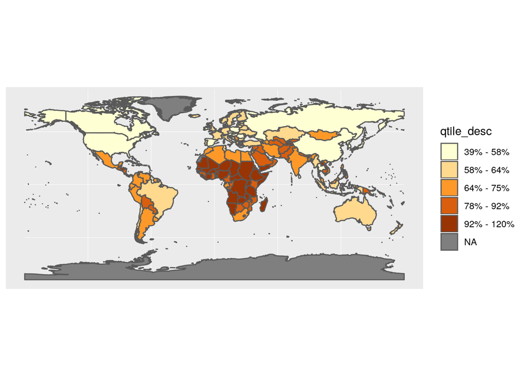

```r
dep_quintiles_sf <- depratio_sf %>%
  arrange(depratio) %>%
  mutate(dep_qtile = ntile(depratio, 5)) %>%
  group_by(dep_qtile) %>%
  ### note: to escape a percent sign in sprintf, use %% - totally not confusing
  mutate(qtile_desc = sprintf('%s%% - %s%%', round(min(depratio)), round(max(depratio))),
         qtile_desc = ifelse(is.na(depratio), NA, qtile_desc), ### for NAs
         qtile_desc = fct_inorder(qtile_desc))

### to check what the data looks like now
# dep_qtiles_df <- dep_quintiles_sf %>%
#   as.data.frame() %>%
#   select(-geometry)

ggplot() +
  geom_sf(data = dep_quintiles_sf, aes(fill = qtile_desc)) +
  scale_fill_brewer(palette = 'YlOrBr',
                    direction = 1,
                    na.value = 'grey50')
```

We’ll store this plot in an object, so it doesn’t immediately print to the screen; instead we’ll `ggsave` it and then include the saved plot instead.

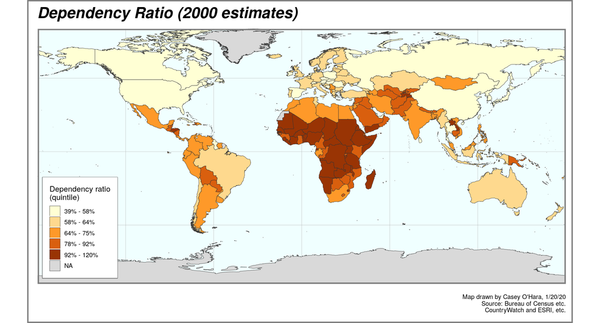

```r
nicer_plot <- ggplot() +
  geom_sf(data = dep_quintiles_sf, aes(fill = qtile_desc),
          color = 'grey20', size = .1) +
  scale_fill_brewer(palette = 'YlOrBr',
                    direction = 1,
                    na.value = 'grey85') +
  theme(text = element_text(size = 6), ### default text
        plot.title = element_text(face = 'bold.italic', size = 12),
        panel.background = element_rect(fill = 'azure1'),
        panel.border = element_rect(color = 'grey50', fill = NA, size = 1),
        panel.grid   = element_line(color = 'grey70', size = .25),
        axis.text = element_blank(),
        axis.ticks = element_blank(),
        legend.key.size = unit(3, 'mm'),
        legend.position = c(.08, .22),
        legend.box.background = element_rect(color = 'grey20', size = .25),
        plot.background = element_rect(color = 'grey50', fill = NA, size = 1)) +
  coord_sf(expand = FALSE) +
  labs(fill =  'Dependency ratio\n(quintile)',
       title = 'Dependency Ratio (2000 estimates)',
       caption = paste("Map drawn by Casey O'Hara, 1/20/20",
                       "Source: Bureau of Census etc.",
                       "CountryWatch and ESRI, etc.",
                       sep = '\n')) ### use \n to get multiple lines

ggsave('basic_plot.png', dpi = 300, width = 6.5, height = 3.5)
```

# Replicating the white-on-black map

```r
coal_sf <- country_data_sf %>%
  select(coal_res = coal_res98) %>%
  mutate(coal_res = ifelse(coal_res < 0, NA, coal_res)) %>%
  arrange(coal_res) %>%
  mutate(coal_cat = case_when(coal_res <= 5000   ~ '0-5B tons',
                              coal_res <= 25000  ~ '5B-25B tons',
                              coal_res <= 100000 ~ '25B-100B tons',
                              coal_res <= 200000 ~ '100B-200B tons',
                              coal_res > 200000  ~ '200B+ tons',
                              TRUE ~ 'No Data'),
         coal_cat = fct_inorder(coal_cat))
```

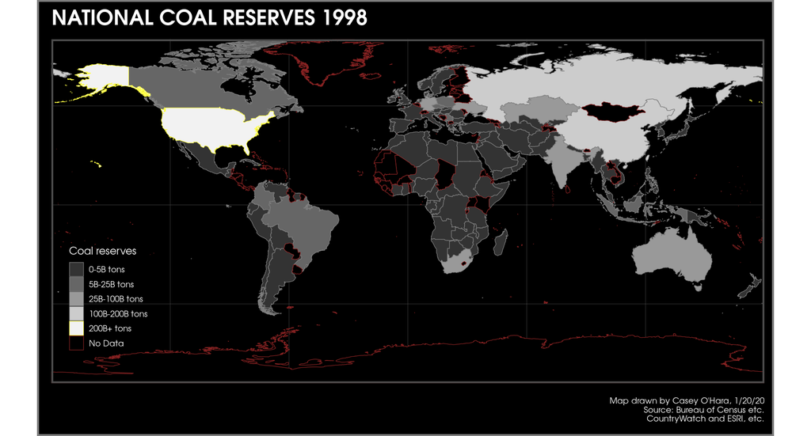

```r
coal_lvls <- levels(coal_sf$coal_cat)
# "0-5B tons"      "5B-25B tons"  "25B-100B tons"
# "100B-200B tons" "200B+ tons"   "No Data"
coal_fills <- c('grey20', 'grey40', 'grey60', 'grey80', 'grey95', 'black')
coal_cols  <- c('grey50', 'grey50', 'grey50', 'grey50', '#ffff44', '#882222')

inverse_plot <- ggplot() +
  geom_sf(data = coal_sf,
          aes(fill = coal_cat, color = coal_cat),
          size = .15) +
  scale_fill_manual(breaks = coal_lvls, values = coal_fills) +
  scale_color_manual(breaks = coal_lvls, values = coal_cols) +
  theme(text = element_text(size = 6, color = 'white', family = 'AvantGarde'),
          ### default text; note AvantGarde might not work on some systems
        plot.title = element_text(face = 'bold', size = 12),
        plot.subtitle = element_text(face = 'bold', size = 9),
        panel.background = element_rect(fill = 'black'),
        panel.border = element_rect(color = 'grey30', fill = NA, size = 1),
        panel.grid   = element_line(color = 'grey30', size = .25),
        axis.text = element_blank(),
        axis.ticks = element_blank(),
        legend.key.size = unit(3, 'mm'),
        legend.key = element_rect(color = NA, fill = NA),
        legend.position = c(.08, .25),
        legend.background = element_rect(fill = NA),
        plot.background = element_rect(color = 'grey50', fill = 'black', size = 1)) +
  coord_sf(expand = FALSE) +
  labs(fill =  'Coal reserves', color = 'Coal reserves',
       title = 'NATIONAL COAL RESERVES 1998',
       caption = paste("Map drawn by Casey O'Hara, 1/20/20",
                       "Source: Bureau of Census etc.",
                       "CountryWatch and ESRI, etc.",
                       sep = '\n')) ### use \n to get multiple lines

ggsave('inverse_plot.png', dpi = 300, width = 6.5, height = 3.5)
```